# Roving Diver Disease Surveys

# Data Visualization

We will now make a number of plots to visualize this prevalence data. The first is plotting disease prevalence at each site over time, grouped by each county. But first we need to subset by **County**. Just a note, *SEFL01* and *SEFL02* are actually *SLR Central* and *SLR South*, respectively. For plotting purposes I am renaming them. I am also arranging the factor levels chronologically.

```r
martin <- subset(countyData, County == "Martin")

class(martin$MonthYear)
```

```
## [1] "character"
```

```r
martin$MonthYear <- as.factor(martin$MonthYear)
levels(martin$MonthYear)
```

```
## [1] "03-19" "04-19" "06-19" "11-17"
```

```r
martin$MonthYear = factor(martin$MonthYear, levels(martin$MonthYear)[c(4, 1, 2, 3)])
levels(martin$MonthYear)
```

```
## [1] "11-17" "03-19" "04-19" "06-19"
```

```r
levels(martin$SiteCode)[levels(martin$SiteCode) == "SEFL01"] <- "SLR Central"
levels(martin$SiteCode)[levels(martin$SiteCode) == "SEFL02"] <- "SLR South"
levels(martin$SiteCode)
```

```
##  [1] "BC1"         "FTL4"        "SLR Central" "SLR South"   "SEFL03"
##  [6] "SEFL04"      "SEFL05"      "SEFL06"      "SEFL08"      "SEFL09"
## [11] "SEFL10"      "SEFL11"      "SEFL12"      "SEFL13"      "SEFL14"
## [16] "SEFL15"      "SEFL16"      "SEFL17"      "SEFL18"      "SEFL19"
## [21] "SEFL19*"     "SEFL20"      "SEFL21"      "SEFL22"      "SLR Ledge"
## [26] "SLR North"   "T328"
```

```r
palm <- subset(countyData, County == "Palm Beach")
class(palm$MonthYear)
```

```
## [1] "character"
```

```r
palm$MonthYear <- as.factor(palm$MonthYear)
levels(palm$MonthYear)
```

```
##  [1] "02-19" "03-19" "04-18" "05-18" "05-19" "06-18" "06-19" "08-18" "12-17"
## [10] "12-18"
```

```r
palm$MonthYear = factor(palm$MonthYear, levels(palm$MonthYear)[c(9, 3, 4, 6, 8, 10, 1, 2, 5, 7)])
levels(palm$MonthYear)
```

```
##  [1] "12-17" "04-18" "05-18" "06-18" "08-18" "12-18" "02-19" "03-19" "05-19"
## [10] "06-19"
```

```r
broward <- subset(countyData, County == "Broward")
class(broward$MonthYear)
```

```
## [1] "character"
```

```r
broward$MonthYear <- as.factor(broward$MonthYear)
levels(broward$MonthYear)
```

```
## [1] "03-19" "05-19" "06-19" "11-18" "12-18"
```

```r
broward$MonthYear = factor(broward$MonthYear, levels(broward$MonthYear)[c(4,5,1,2,3)])
levels(broward$MonthYear)
```

```
## [1] "11-18" "12-18" "03-19" "05-19" "06-19"
```

Plot for Martin County

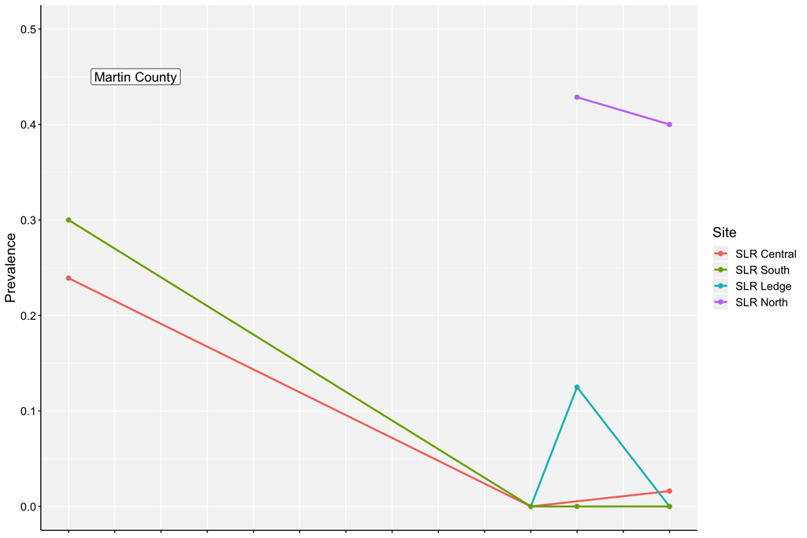

```r
martin.prev.plot1 <-
  ggplot(martin, aes(x=MonthYear, y=Prevalence, color = SiteCode, group = SiteCode, label=SiteCode))+
  geom_line(size = 1)+
  geom_point(size = 2)+
  labs(y = "Prevalence")+
    annotate("label", x = 2.45, y = 0.45, label = paste ("Martin County"), size = 5)+
  scale_x_discrete(limits = c("11-17","12-17","01-18", "04-18", "05-18", "06-18", "08-18", "11-18", "12-18", "02-19", "03-19", "04-19", "05-19", "06-19"), labels = c("Nov 17","Dec 17","Jan 18", "Apr 18", "May 18", "Jun 18", "Aug 18", "Nov 18", "Dec 18", "Feb 19", "Mar 19", "Apr 19", "May 19", "Jun 19"))+
  labs(color = "Site")+
  ylim(0,0.5)

# takes the legend and saves it as a separate object (grob)
get_legend<-function(martin.prev.plot1){
  tmp <- ggplot_gtable(ggplot_build(martin.prev.plot1))
  leg <- which(sapply(tmp$grobs, function(x) x$name) == "guide-box")
  martin.legend <- tmp$grobs[[leg]]
  return(martin.legend)
}
martin.legend=get_legend(martin.prev.plot1)



martin.prev.plot <- martin.prev.plot1 +
  theme(panel.grid.major = element_line(size = 0.5, linetype = 'solid', colour = "white"),
        panel.background = element_rect(fill = '#F5F5F5'),
        plot.title = element_text(hjust = 0.5),
        axis.line = element_line(colour = "black"),
        axis.ticks = element_line(color="black"),
        text = element_text(size=15, color="black"),
        axis.title.x=element_blank(),
        axis.text.x=element_blank(),
        axis.text.y=element_text(size=12, color="black")
        )


martin.prev.plot
```

Plot for Palm Beach County

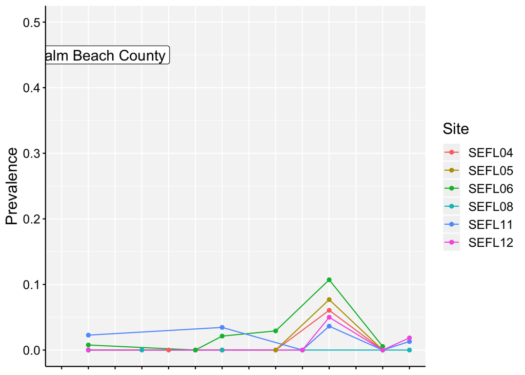

```r
palm.prev.plot1 <-
  ggplot(palm, aes(x=MonthYear, y=Prevalence, color = SiteCode, group = SiteCode, label = SiteCode))+
  geom_line()+
  geom_point()+
  annotate("label", x = 2.45, y = 0.45, label = paste ("Palm Beach County"), size = 5)+
  scale_x_discrete(limits = c("11-17","12-17","01-18", "04-18", "05-18", "06-18", "08-18", "11-18", "12-18", "02-19", "03-19", "04-19", "05-19", "06-19"), labels = c("Nov 17","Dec 17","Jan 18", "Apr 18", "May 18", "Jun 18", "Aug 18", "Nov 18", "Dec 18", "Feb 19", "Mar 19", "Apr 19", "May 19", "Jun 19"))+
    labs(color = "Site")+
  ylim(0,0.5)


# takes the legend and saves it as a separate object (grob)
legend<-function(palm.prev.plot1){
  tmp <- ggplot_gtable(ggplot_build(palm.prev.plot1))
  leg <- which(sapply(tmp$grobs, function(x) x$name) == "guide-box")
  martin.legend <- tmp$grobs[[leg]]
  return(palm.legend)
}
palm.legend=get_legend(palm.prev.plot1)



palm.prev.plot <- palm.prev.plot1+
  theme(panel.grid.major = element_line(size = 0.5, linetype = 'solid', colour = "white"),
        panel.background = element_rect(fill = '#F5F5F5'),
        plot.title = element_text(hjust = 0.5),
        axis.line = element_line(colour = "black"),
        axis.ticks = element_line(color="black"),
        text = element_text(size=15, color="black"),
        axis.title.x=element_blank(),
        axis.text.x=element_blank(),
        axis.text.y=element_text(size=12, color="black")
        )

palm.prev.plot
```

Plot for Broward County

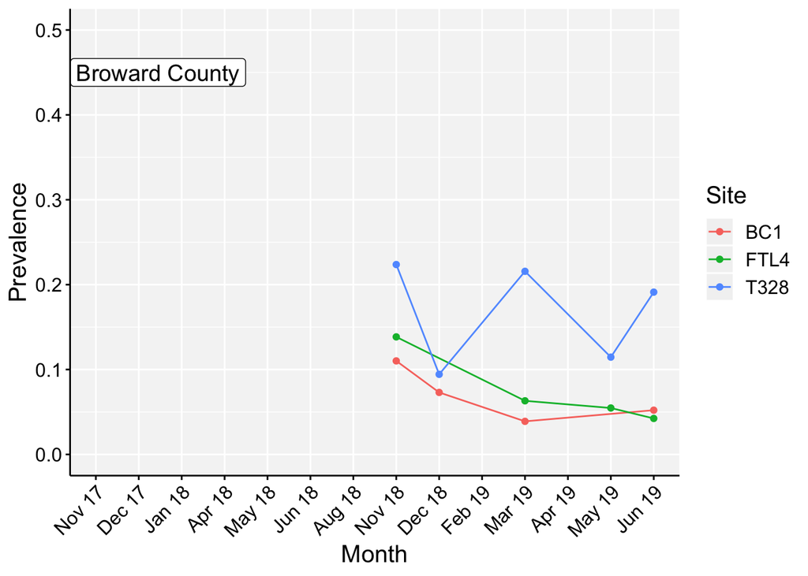

```r
broward.prev.plot1 <-
  ggplot(broward, aes(x=MonthYear, y=Prevalence, color = SiteCode, group = SiteCode, label = SiteCode))+
  geom_line()+
  geom_point()+
  scale_x_discrete(limits = c("11-17","12-17","01-18", "04-18", "05-18", "06-18", "08-18", "11-18", "12-18", "02-19", "03-19", "04-19", "05-19", "06-19"), labels = c("Nov 17","Dec 17","Jan 18", "Apr 18", "May 18", "Jun 18", "Aug 18", "Nov 18", "Dec 18", "Feb 19", "Mar 19", "Apr 19", "May 19", "Jun 19"))+
  ylim(0,0.5)+
  annotate("label", x = 2.45, y = 0.45, label = paste ("Broward County"), size = 5) +
  labs(y = "Prevalence", x = "Month", color = "Site")



legend<-function(broward.prev.plot1){
  tmp <- ggplot_gtable(ggplot_build(broward.prev.plot1))
  leg <- which(sapply(tmp$grobs, function(x) x$name) == "guide-box")
  martin.legend <- tmp$grobs[[leg]]
  return(broward.legend)
}
broward.legend=get_legend(broward.prev.plot1)


broward.prev.plot <- broward.prev.plot1+
  theme(panel.grid.major = element_line(size = 0.5, linetype = 'solid', colour = "white"),
        panel.background = element_rect(fill = '#F5F5F5'),
        plot.title = element_text(hjust = 0.5),
        axis.line = element_line(colour = "black"),
        axis.ticks = element_line(color="black"),
        text = element_text(size=15, color="black"),
        axis.text.x=element_text(angle = 45, hjust = 1,size=12, color="black"),
        axis.text.y=element_text(size=12, color="black")
        )

broward.prev.plot
```

You might have noticed that only the Broward County plot had labels and titles along the x-axis. That is because we are going to stack the plots using *patchwork* and saving it in our figures folder.

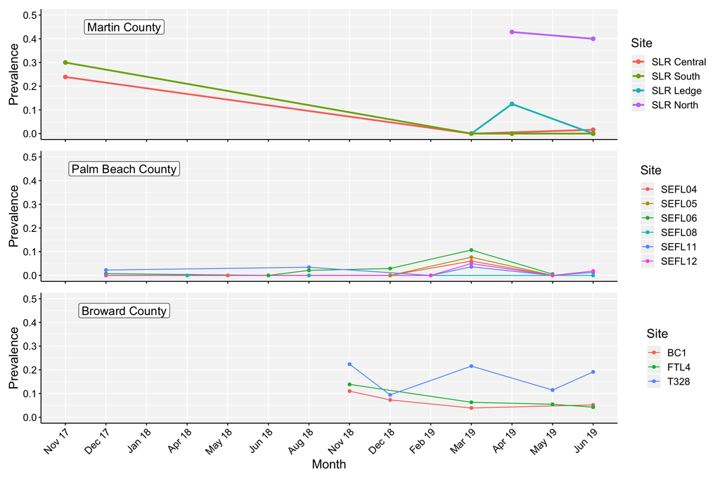

```r
stacked.plot <- (martin.prev.plot / palm.prev.plot / broward.prev.plot)

ggsave("../figures/site.prevalence.png", plot= stacked.plot, width=12, height=8, units="in", dpi=600)

stacked.plot
```